# Clasificación Automática de niveles de actividad en Acelerometría

4 Nov 2019

## El Problema

## El Problema

#### ¿ Cuánto ejercicio hace una persona ?

- …¿ Cómo *medir* la cantidad de ejercicio físico que desarrolla una persona ?
- Utilidad:
- …Diagnosis: *problemas durante el sueño (APNEA, …), …*
- …Terapia: *tratamiento y recuperación de diferentes dolencias, …*
- …Estudios del Metabolismo: *…obesidad, eficiencia muscular…*
- …Entrenamiento deportivo: *…mejoras físicas de todo tipo*
- …Prevención: *…de dolencias en la 3ra. edad, …de riesgo Cardiovascular, de …*

## Soluciones

## Móviles, Relojes digitales y Apps

- *Activity trackers*, *Training*, *Running*, *Fitness*, *Workout Planners*,*…* [10 Best Fitness Apps For Android (2019) – Track Your Workouts](https://fossbytes.com/best-fitness-apps-android/)  
  …Mayormente preparadas para usar GPS y medir *lo que se anda o corre*
- …Presentaciones magníficas, mediciones dudosas (*pasos, km, kc consumidas, …*)
- …Aparente falta de rigor en las cuentas metabólicas:  
  [Fibit](https://www.fitbit.com/es/home) *acusado* por hacer **lecturas imprecisas del pulso**:
  - https://www.theverge.com/2016/1/6/10724270/fitbit-lawsuit-charge-hr-surge-incomplete-heart-rate-tracking
  - https://mashable.com/2016/01/08/fitbit-lawsuit-inaccurate-heart-rate-monitors/?europe=true
- …Además:
  - ¡¡ …Negocio !!
  - ¡¡ …Cruce de datos en la nube !!
- Otro igrediente (además del GPS): **Acelerómetro** (¿¡ …sin giróscopo !?)  
  (*¡¡ Se usa para medir los pasos !!*, footpods)

## Acelerometría

- [Uso médico de la accelerometría](https://en.wikipedia.org/wiki/Accelerometer#Medical_applications)
  - [El sensor acelerométrico](https://learn.sparkfun.com/tutorials/accelerometer-basics/all)
  - …[GENEActiv](https://www.activinsights.com/products/geneactiv/), [actiGraph](https://www.actigraphcorp.com/), …
  - [Accelerometer Data Collection and Processing Criteria to Assess Physical Activity and Other Outcomes: A Systematic Review and Practical Considerations,Migueles et Al.](https://www.ncbi.nlm.nih.gov/pmc/articles/PMC6231536/)
- Usar acelerómetros en dispositivos portátiles
  - Acelerómetros de muñeca, cintura, pecho, …
  - Combinaciones varias…
  - …

## Acelerometría

- **IDEA:**  
  *La aceleración \(A\) en una parte del cuerpo refleja el movimiento del cuerpo, lo que a la postre refleja el grado de actividad \(L\) de una persona*

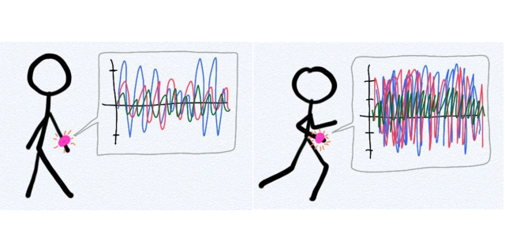

## Acelerometría

No todo es perfecto:

- *Non Wear Problem:* ¡¡…Cuando no se lleva puesto, los datos que proporciona no valen !!
- *Activity Categorization Problem:* …¿ Qué es reposo, activdad ó actividad vigorosa ?
- *Bout Problem:* …¿ Cómo detectar el ejercicio continuado ?
- *Problemas asociados al dispositivo/procedimiento de medida:*
  - Calibración de los datos obtenidos del dispositivo
  - Localización del dispositivo en la persona
  - …Cada persona es diferente: *anatómicamente* y *conductualmente*.

## Plan

### …Desarrollar un modelo para estudiar y categorizar el *nivel de actividad*

- Los datos
- …Preprocesamiento
- …Dos ejemplos: `nonWearNight.RData`, `nadador.RData`
- EL Modelo y su estimación
- Resultados
- Comentarios finales

## Los datos

## Los datos

- `nonWearNight.RData`: 7 días a 10Hz, 35Mb.  
  7 x 24 x 3600 x 10=6048000 obs.
  - Variables `time`, `ax`, `ay` `az` (acel. en los tres ejes), `lux`, `button`, `temp`
  - Modelo de sensor acelerométrico: GENEActiv Original.
- Experimento desarrollado por estudiantes del grupo GENUD (Growth, Exercise, Nutrition and Development) para estudiar la detección de periodos *Nonwear*

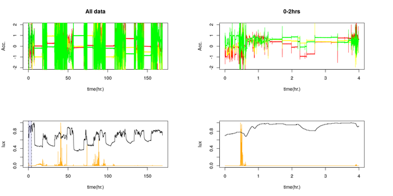

## Los datos

- `nadador.RData`: 7 días a 30Hz, 69Mb.  
  7 x 24 x 3600 x 30=18144000 obs.
- Variables `time`, `ax`, `ay` `az` (acel. en los tres ejes), `lux`, `button`, `temp`
  - Modelo de sensor acelerométrico: GENEActiv Original.
  - Datos acelerómetro mano izquierda seguimiento nadador (2014-07-02 15-46-48, Ref. 018532).

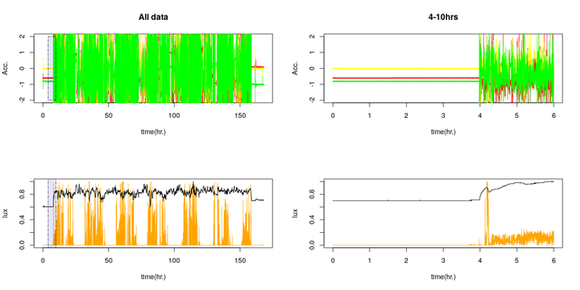

## Preprocesamiento

#### Los datos no se usan *en crudo*

- …Se crean nuevas variables:  
  *Para cada observación, para cada instante \(t\) se calcula*:
  - `EN`: Módulo del vector aceleración \[ EN_i=\sqrt{a_{xt}^2+a_{yt}^2+a_{zt}^2} \]
  - `ENMO`: aceleración sin el efecto de la gravedad !! \[ ENMO_i=\sqrt{a_{xt}^2+a_{yt}^2+a_{zt}^2}-1 \] …otra versión \[ ENMO_i=\max(\sqrt{a_{xt}^2+a_{yt}^2+a_{zt}^2}-1,0) \]

## Preprocesamiento

#### Los datos se *agregan*

- Obviamente: los datos están muy correlados
- …Pero esto cambia al considerar **intervalos o épocas** de tiempo que no se solapan.
- …Las distribuciones de \(a_{xt}, a_{yt}, a_{zt}\), y en particular las de \(ENMO_i\) ó \(EN_i\) de **intervalos o épocas de tiempo consecutivas**:
  - …No comparten la misma distribución (KW)
  - …Menos de un 20% comparten la misma media y varianza
  - pero…

## Preprocesamiento

#### Se estudia el comportamiento por *Épocas*

- Se analiza el comportamiento agregado por *épocas*:  
  **Época**: intervalo de tiempo para el que se calculan datos agregados
  - Para gente muy activa (niños y/o deportistas): …épocas de 15sg.
  - Para gente normal (adultos en general): …épocas de 30-60sg.
- …Para cada *Época* \(T\) se calcula la media de \(EN_t\), \(EN^2_t\), \(ENMO_t\): \[ {\overline{EN}}_T, {\overline{EN^2}}_T, {\overline{ENMO}}_T\ \ \ \ \textrm{si}\ \ t\in T \]

## …Épocas de `nonWearNight.RData`

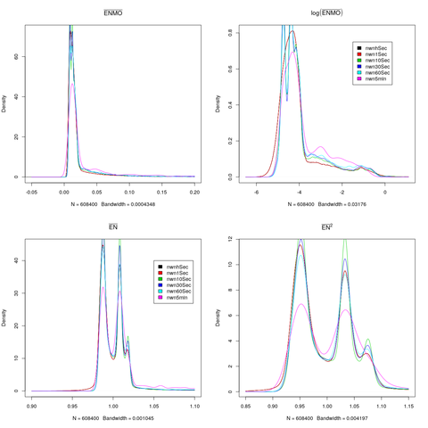

## …Épocas de `nadador.RData`

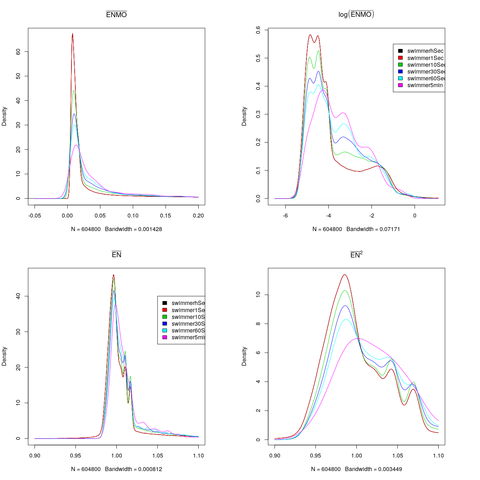

## EL Modelo

## Modelo con Variables Ocultas

Si \(A_T\) es la *medida de la aceleración* considerada ( \({\overline{EN}}_T, {\overline{EN^2}}_T, {\overline{ENMO}}_T\) ó \({\overline{\log ENMO}}\) ), y \(L_T\) es el *nivel de actividad* de la *época* \(T\)

- Se considera que para cualquier persona se cumple que
  - *¡¡…A más nivel de actividad, más aceleración tiene el cuerpo !!*
- La aceleración \(A_T\) *depende* del nivel de actividad \(L_T\) \[ A_T=a | L_T=l\sim{ {{f}\kern-2pt\left( {a|\theta_l} \right)} } \]
- La probabilidad de que en una *época* \(T\) una persona esté en un *nivel de actividad* \(l\) es \({ {\mathbf{P}\kern-2pt\left( L_T \right)} }=p_l\) ( ¡¡…proporción de tiempo en nivel \(l\) !!)

## Modelo con Variables Ocultas

- Como consecuencia: \[ \begin{align*} { {\mathbf{P}\kern-2pt\left( A_T=a | L_T=l \right)} } & = & { {{f}\kern-2pt\left( {a|\theta_l} \right)} }\,da \\ { {\mathbf{P}\kern-2pt\left( A_T=a ,L_T=l \right)} } & = & p_l\ { {{f}\kern-2pt\left( {a|\theta_l} \right)} }\,da \\ \end{align*} \]
- **Problema:**
  - …Sólo se observa la *medida de la aceleración* \(A_T\)
- *¡¡ No hay información sobre el* **nivel de actividad** \(L_T\) !!
- …Y sin embargo, si \(\theta_T\) y \(p_l\) son *conocidos* : \[ p^*_l={ {\mathbf{P}\kern-2pt\left( L_T=l | A_T=a \right)} } = \frac{ { {{f}\kern-2pt\left( {a|\theta_l} \right)} }\ p_l } { \sum_l { {{f}\kern-2pt\left( {a|\theta_l} \right)} }\ p_l } \]

## Estimación

## Estimación: *Algoritmo E.M.*

#### …Se usa el algoritmo Expectation-Maximization

- **Expectation:**  
  ¡¡ …Tomar esperanzas respecto del *nivel de actividad* !!
- **Maximization:**  
  ¡¡ …\(\theta_1,\dots,\theta_T\) Maximiza el la esperanza anterior !!
- **Ecuaciones:**  
  Los datos son las aceleraciones \(a_1,\dots,a_n\) de las *épocas* observadas y hay \(M\) *estados de actividad* \[ \begin{align*} \arg\max_{\theta_l,p_l\ l=1,\dots,M} \sum_{i=1}^n\sum^M_{l=1} \log { {{f}\kern-2pt\left( {a_i|\theta_l} \right)} }\ p^*_l + \sum_{i=1}^n\sum^M_{l=1} \log p_l\ p^*_l \end{align*} \]
- El algoritmo *itera* el cálculo de \(p^*_l\) junto con este problema de maximización

## El Código

## Código para el modelo

- …Las densidades \({ {{f}\kern-2pt\left( {a|\theta_l} \right)} }\) se dan como una familia de funciones:

  ```
  ...
  densFunc = function(dat,theta)
          outer(dat,theta,function(x,m) rDensFun(x,p1=m[[1]],...)),
  ...
  ```

- El valor de la densidad en cada dato \({ {{f}\kern-2pt\left( {a_i|\theta_l} \right)} }\) es

  ```
  densDataClass<-densFunc(dat,theta)
  ```

## Código para la estimación

- Estimación de \(\theta_1,\dots,\theta_T\) con `optim( ... )`:

  ```
  ff <- function(theta) {
    aa<-densFunc(dat,theta)
    ... ## mirar los 0s de aa !!
  sum( -log( aa )%*%diag(probClas) )
  }
  densPars <- optim(densPars,ff)$par
  ```

- Estimación \(p_l\) (`probClass`)

  ```
  probClass <- prop.table(densDataClass%*%diag(probClas),1)
  ```

## Resultados

## Resultados `nonWearNight.RData`

- Modelo: \(M=5\) grupos con \({ {{f}\kern-2pt\left( {a_i|\theta_l} \right)} }\) es \({ {{N}\kern-2pt\left( {\mu,0.5} \right)} }\)

```r
nwn60SecENMOlog <- log(nwn60Sec$mean.ENMO.)
emLogEnmo60Sol51<-myEmEstimProc(
  dd=nwn60SecENMOlog,
  densFunc = function(dat,theta)
        outer(dat,theta,function(x,m)dnorm(x,mean=m,sd=.5)),
  densPars = c(-5,-4,-3,-1,0),
  probClas = c(0.2,0.2,0.2,0.2,0.2)
)
```

## Resultados `nonWearNight.RData`

- Predicciones numéricas \({ {\mathbf{P}\kern-2pt\left( A_T=a | L_T=l \right)} }\):

```r
fit60Sol51<-predictMyEmEstimProc(emLogEnmo60Sol51)
```

```
##           [,1]      [,2]         [,3]         [,4]         [,5]
## [1,] 0.3866400 0.5945014 1.885805e-02 4.860891e-07 2.530578e-09
## [2,] 0.4013386 0.5985697 9.173386e-05 2.211901e-11 4.425584e-14
## [3,] 0.4046683 0.5953234 8.309851e-06 2.455743e-13 3.197341e-16
## [4,] 0.4006012 0.5992445 1.542719e-04 5.859761e-11 1.286709e-13
## [5,] 0.4004951 0.5993388 1.661255e-04 6.731864e-11 1.497920e-13
## [6,] 0.3994392 0.6002195 3.412683e-04 2.595119e-10 6.568456e-13
```

- Clasificación (Predicciones de las clases) \(L_T\):

```r
class60Sol51<-predictMyEmEstimProc(emLogEnmo60Sol51,type="class")
```

```
## [1] 2 2 2 2 2 2
```

## Resultados `nonWearNight.RData`

- Estimación \(p_l\):

```r
emLogEnmo60Sol51$optim$probClas
```

```
## [1] 0.320816353 0.484460780 0.112241067 0.074335160 0.008146641
```

- Estimación \(\theta_l\) y \({ {{f}\kern-2pt\left( {a_i|\theta_l} \right)} }\):

```r
emLogEnmo60Sol51$optim$densPars
```

```
## [1] -4.325326 -4.316179 -2.716513 -1.315048 -1.028191
```

```r
emLogEnmo60Sol51$densFunc
```

```
## function(dat,theta)
## outer(dat,theta,function(x,m)dnorm(x,mean=m,sd=.5))
## <bytecode: 0x5609166859f0>
```

## Resultados `nonWearNight.RData`

- Gráfico predicción de los *niveles de actividad*

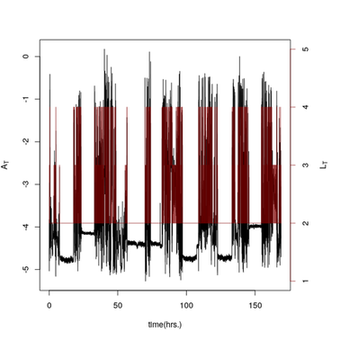

## Resultados `nonWearNight.RData`

- Gráfico densidad \(A_T\) en cada *niveles de actividad*

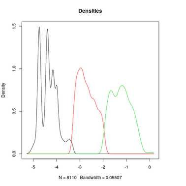

## Resultados `nonWearNight.RData`

- Desc. de los *niveles de actividad*

```r
fit60Sol51Agg
```

```
##   class60Sol51 nwn60SecENMOlog.mean nwn60SecENMOlog.sd
## 1            2           -4.3339917          0.3702409
## 2            3           -2.7071026          0.3686726
## 3            4           -1.2268487          0.4236892
```

- Proporción de tiempo en los *niveles de actividad*

```r
100*prop.table( table(class60Sol51) )
```

```
## class60Sol51
##         2         3         4
## 79.980276 12.001972  8.017751
```

## Resultados `nadador.RData`

- Modelo: \(M=5\) grupos con \({ {{f}\kern-2pt\left( {a_i|\theta_l} \right)} }\) es \({ {{N}\kern-2pt\left( {\mu,0.5} \right)} }\)

```r
nwn60SecENMOlog <- log(swimmer60Sec$mean.ENMO.)
emLogEnmo60Sol51<-myEmEstimProc(
  dd=nwn60SecENMOlog,
  densFunc = function(dat,theta)
        outer(dat,theta,function(x,m)dnorm(x,mean=m,sd=.5)),
  densPars = c(-5,-4,-3,-1,0),
  probClas = c(0.2,0.2,0.2,0.2,0.2)
)
```

## Resultados `nadador.RData`

- Gráfico predicción de los *niveles de actividad*

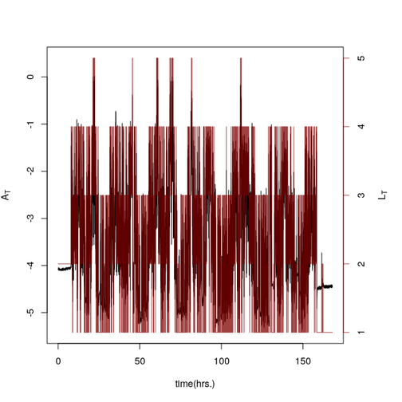

## Resultados `nadador.RData`

- Gráfico densidad \(A_T\) en cada *niveles de actividad*

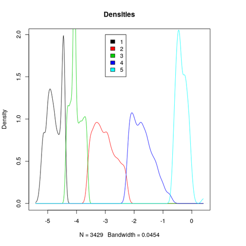

## Resultados `nadador.RData`

- Desc. de los *niveles de actividad*

```r
fit60Sol51Agg
```

```
##   class60Sol51 swimmer60SecENMOlog.mean swimmer60SecENMOlog.sd
## 1            1               -4.7694738              0.2569401
## 2            2               -4.0191017              0.2042178
## 3            3               -3.0182469              0.3760021
## 4            4               -1.7048664              0.3672460
## 5            5               -0.3507907              0.1860552
```

- Proporción de tiempo en los *niveles de actividad*

```r
100*prop.table( table(class60Sol51) )
```

```
## class60Sol51
##         1         2         3         4         5
## 34.017857 21.279762 29.275794 14.305556  1.121032
```

## Algunos comentarios

## Comentarios

- …En contra:
  - … ¿¡ es correcto el modelo !?
    - ¿ Cuál es el número de *niveles de actividad* \(M\) ?
    - No es objetivo: *Estima algo inobservable*
    - No es objetivo: *No hay una medición directa de la actividad*
  - No da información metabólica
  - El algoritmo E.M. es iterativo (*Lento*) y hay muchos datos

## Comentarios

- …A favor:
  - El modelo, en tanto que expresa *asociación* entre la *aceleración* y el *nivel de actividad* es correcto. Impreciso, pero tiene sentido
  - ¡¡ Se adapta al lugar en que se lleve el dispositivo, y a la persona !!
  - El modelo proporciona herramientas para comparar niveles de actividad y clasificación de individuos
- E.M. es muy flexible. El modelo propuesto es muy simple, posibles mejoras:
  - …usar los datos multivariantes
  - …usar estimadores habituales (MSE o MM) de \(\theta_l\)…
  - …usar estimadores noparamétricos de \({ {{f}\kern-2pt\left( {a|\theta_l} \right)} }\) !?…
  - …Modelo más complejos: …persistencia en el *nivel de actividad*, …utilizar vector aceleración, …otros sensores
  - …

## …Muchas gracias

- …Más ejemplos